# Results for VDBA Scaling Analysis

O.W.

2025-11-10

# Comapre 5 seconds and 1 second windows

To demonstarte that these are interchangable and results not affected by the length of the window

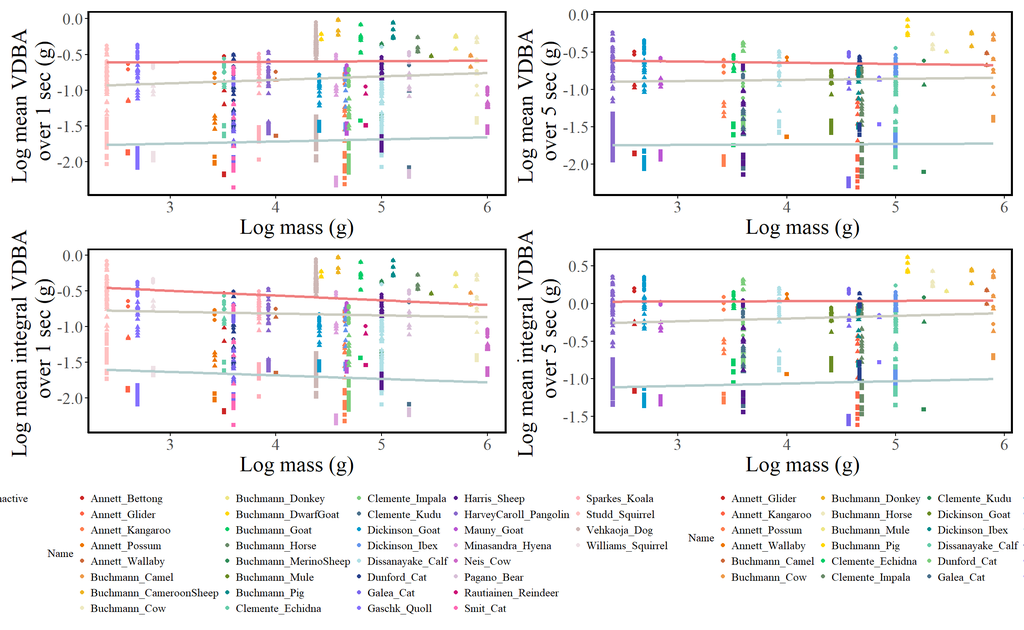

## All species pooled

All species, with approximate/average masses.

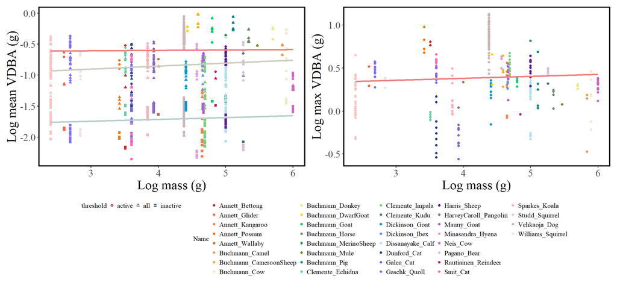

```
## # A tibble: 7 × 9
##   effect term          estimate std.error statistic    df p.value sig   variable
##   <chr>  <chr>            <dbl>     <dbl>     <dbl> <dbl>   <dbl> <chr> <chr>
## 1 fixed  LogMass         0.0429    0.0414     1.04   552. 0.301   not … mean
## 2 fixed  LogMass:thre…   0.0952    0.0385     2.47   620. 0.0136  sig   mean
## 3 fixed  LogMass:thre…   0.121     0.0402     3.01   630. 0.00271 sig   mean
## 4 fixed  LogMass         0.0338    0.0464     0.729  314. 0.467   not … max
## 5 fixed  LogMass        -0.124     0.0434    -2.86   526. 0.00446 sig   int
## 6 fixed  LogMass:thre…   0.0951    0.0385     2.47   620. 0.0139  sig   int
## 7 fixed  LogMass:thre…   0.122     0.0403     3.04   629. 0.00250 sig   int
```

## Only Datasets With Long Data

Maybe some of the small datasets are skewing it… Exclude datasets that had less than 24 hrs worth of data.

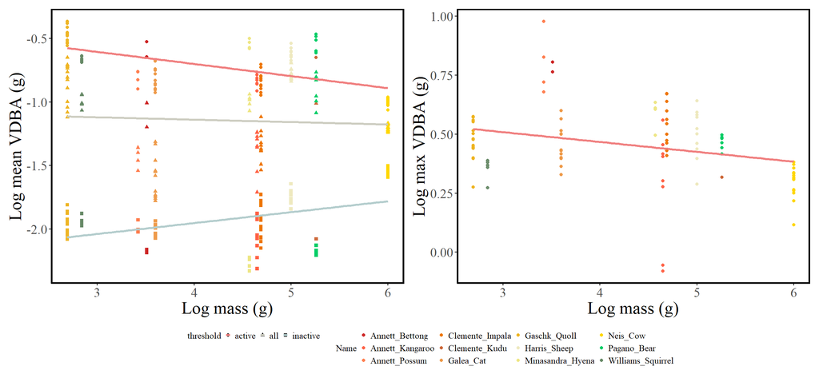

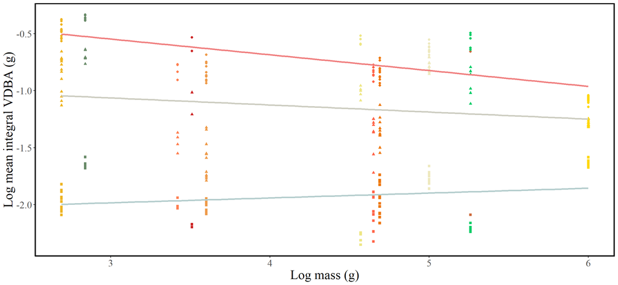

```
## # A tibble: 7 × 9
##   effect term         estimate std.error statistic    df  p.value sig   variable
##   <chr>  <chr>           <dbl>     <dbl>     <dbl> <dbl>    <dbl> <chr> <chr>
## 1 fixed  LogMass        -0.223    0.0463     -4.81 252.  2.55e- 6 sig   mean
## 2 fixed  LogMass:thr…    0.176    0.0595      2.96 197.  3.49e- 3 sig   mean
## 3 fixed  LogMass:thr…    0.417    0.0595      7.00 197.  3.87e-11 sig   mean
## 4 fixed  LogMass        -0.115    0.0337     -3.40  84.9 1.02e- 3 sig   max
## 5 fixed  LogMass        -0.321    0.0499     -6.43 224.  7.39e-10 sig   int
## 6 fixed  LogMass:thr…    0.176    0.0596      2.95 198.  3.58e- 3 sig   int
## 7 fixed  LogMass:thr…    0.416    0.0596      6.98 198.  4.33e-11 sig   int
```

## Collar Data Only

And then only the sepcies that were on a collar.

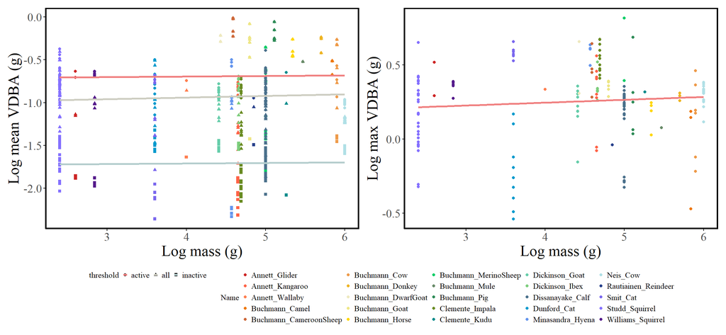

```
## # A tibble: 7 × 9
##   effect term          estimate std.error statistic    df p.value sig   variable
##   <chr>  <chr>            <dbl>     <dbl>     <dbl> <dbl>   <dbl> <chr> <chr>
## 1 fixed  LogMass         0.0271    0.0478     0.568  256. 5.71e-1 not … mean
## 2 fixed  LogMass:thre…   0.0291    0.0386     0.753  314. 4.52e-1 not … mean
## 3 fixed  LogMass:thre…   0.121     0.0406     2.99   318. 3.04e-3 sig   mean
## 4 fixed  LogMass         0.0445    0.0376     1.18   177. 2.38e-1 not … max
## 5 fixed  LogMass        -0.196     0.0507    -3.86   246. 1.47e-4 sig   int
## 6 fixed  LogMass:thre…   0.0290    0.0387     0.750  316. 4.54e-1 not … int
## 7 fixed  LogMass:thre…   0.126     0.0407     3.09   320. 2.16e-3 sig   int
```

## Single system analysis

What is the differences in sampling protocol are throwing it out? Collected only data collected in the same way by the same lab. # V1: Clemente There were insufficint individuals, so removed ID as an effect and just had a linear model.

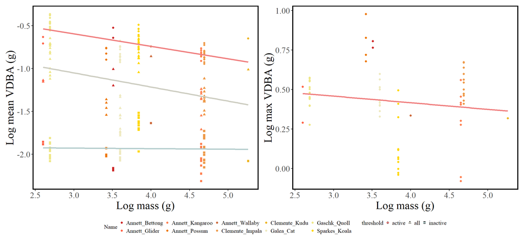

```
## # A tibble: 4 × 7
##   term                      estimate std.error statistic  p.value sig   variable
##   <chr>                        <dbl>     <dbl>     <dbl>    <dbl> <chr> <chr>
## 1 LogMass                    -0.336     0.0801    -4.20   4.07e-5 sig   mean
## 2 LogMass:thresholdall       -0.0428    0.113     -0.378  7.06e-1 not … mean
## 3 LogMass:thresholdinactive   0.322     0.113      2.84   4.96e-3 sig   mean
## 4 LogMass                    -0.0965    0.0802    -1.20   2.33e-1 not … max
```

# V2: Buchmann

Similarly ID was not a random effect here as too few individuals.

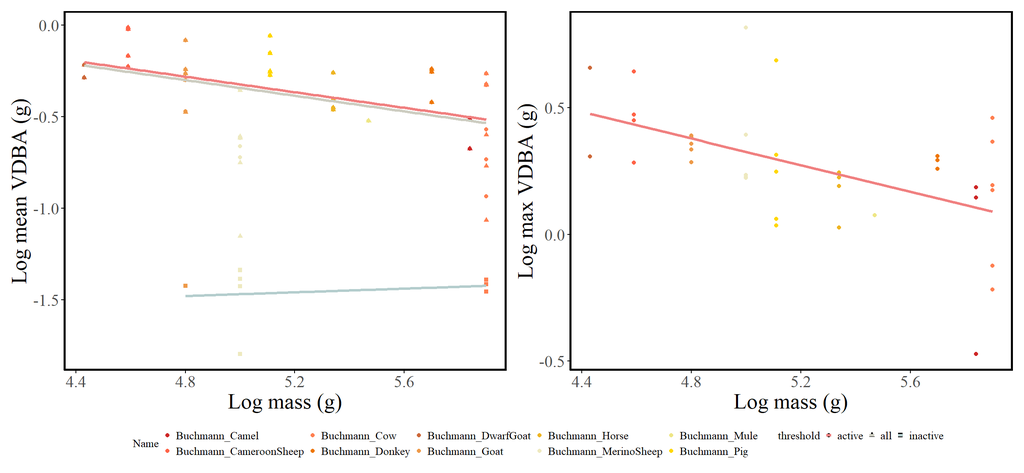

```
## # A tibble: 4 × 7
##   term                      estimate std.error statistic  p.value sig   variable
##   <chr>                        <dbl>     <dbl>     <dbl>    <dbl> <chr> <chr>
## 1 LogMass                   -0.489       0.164   -2.98   0.00383  sig   mean
## 2 LogMass:thresholdall      -0.00266     0.232   -0.0115 0.991    not … mean
## 3 LogMass:thresholdinactive  0.605       0.408    1.48   0.142    not … mean
## 4 LogMass                   -0.602       0.160   -3.75   0.000614 sig   max
```

# Pooled

Maybe the species masses are too vauge… what if we only use the datasets where we know the exact mass? Again, just a linear model with no random effect for ID.

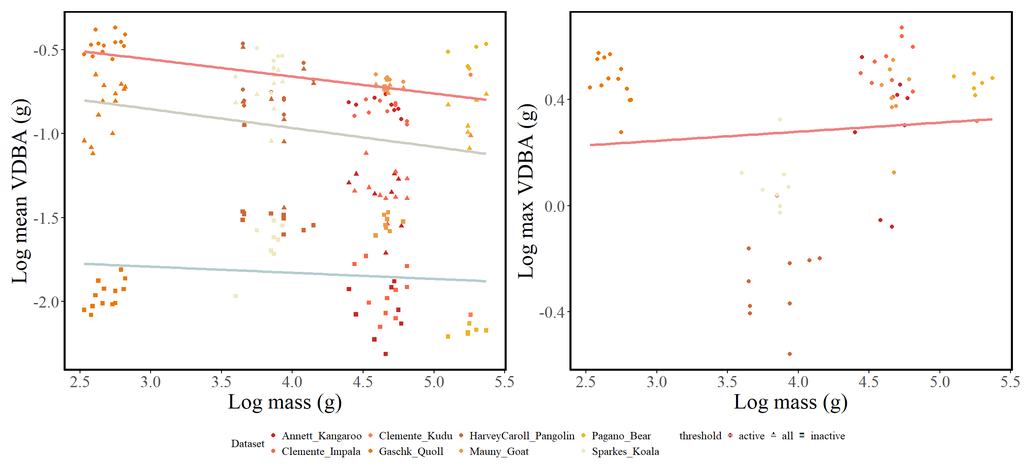

```
## # A tibble: 4 × 7
##   term                      estimate std.error statistic p.value sig    variable
##   <chr>                        <dbl>     <dbl>     <dbl>   <dbl> <chr>  <chr>
## 1 LogMass                    -0.233     0.0786    -2.96  0.00345 sig    mean
## 2 LogMass:thresholdall       -0.0254    0.111     -0.228 0.820   not s… mean
## 3 LogMass:thresholdinactive   0.149     0.111      1.34  0.182   not s… mean
## 4 LogMass                     0.0795    0.104      0.763 0.448   not s… max
```

# Even further separated

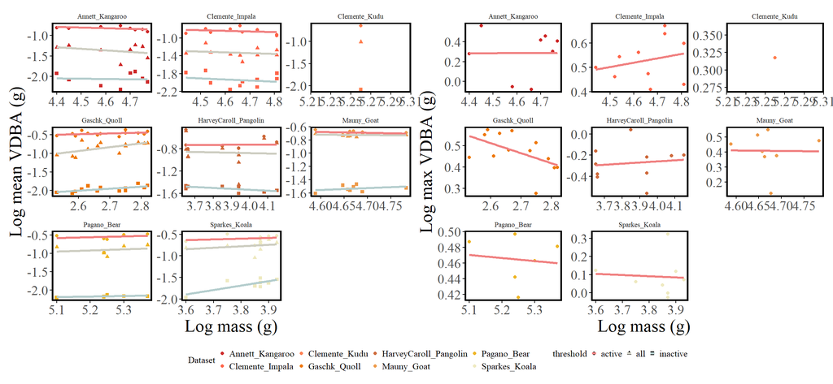

## Understanding the animal activity

# Find the active minutes per day

Is there a mass-mediated effect on activity patterns generally

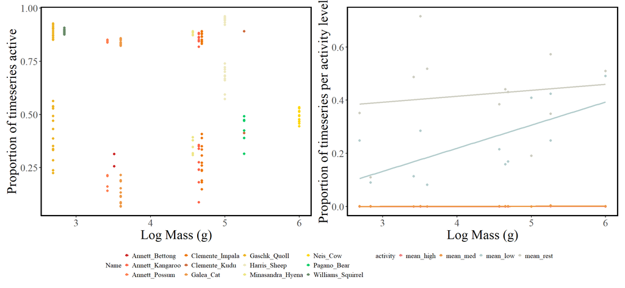

## Understanding the distribution of activity

Does the distibution of high and low VDBA differ with size?

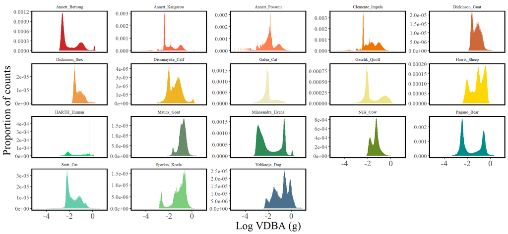